# EDA of Medicare Inpatient Charge Data

Anand Raman

12/9/2018

# Loading Packages

```r
library(tidyverse)
library(ggstance)
library(usmap)
```

# Datasets

For this project I used data from the Centers for Medicare and Medicaid Services. Both datasets fall under the category of Medicare and Provider Utilization Payment Data: Inpatient. This means the charge data is entirely composed of discharges and billings for inpatient treatments and diagnoses (heart transplants, septicemia treatments, joint replacements etc.) Specifically, I use data from 2015 and 2016 – the most recently published data. I have merged the two datasets to enable comparison. Details of the merging process can be found in cleaning_merging.R.

Brief note on terminology: In this data, the abbreviations CC and MCC stand for “complication or comorbidity” and “major complication or comorbidity” respectively. Comorbidity is the presence of two or more chronic conditions in a patient.

### Reading in Data

```r
med <- read_csv("data/processed/medicare_inpatient_15_16.csv")
```

# Analysis

#### Most Common Inpatient Charges

I will display the most commonly diagnosed issues across both years, taking the sum of total number of discharged patients across years 2015 and 2016.

```r
med %>%
  gather(tot_discharges_15,
         tot_discharges_16,
         key = tot_by_yr,
         value = tot_discharges) %>%
  group_by(drg_definition) %>%
  summarise(tot_discharges = sum(tot_discharges)) %>%
  arrange(desc(tot_discharges)) %>%
  slice(1:10)
```

```
## # A tibble: 10 x 2
##    drg_definition                                           tot_discharges
##    <chr>                                                             <int>
##  1 470 - MAJOR JOINT REPLACEMENT OR REATTACHMENT OF LOWER …         860198
##  2 291 - HEART FAILURE & SHOCK W MCC                                401477
##  3 292 - HEART FAILURE & SHOCK W CC                                 329721
##  4 872 - SEPTICEMIA OR SEVERE SEPSIS W/O MV >96 HOURS W/O …         266111
##  5 690 - KIDNEY & URINARY TRACT INFECTIONS W/O MCC                  260930
##  6 683 - RENAL FAILURE W CC                                         254155
##  7 193 - SIMPLE PNEUMONIA & PLEURISY W MCC                          248957
##  8 194 - SIMPLE PNEUMONIA & PLEURISY W CC                           242524
##  9 190 - CHRONIC OBSTRUCTIVE PULMONARY DISEASE W MCC                241138
## 10 189 - PULMONARY EDEMA & RESPIRATORY FAILURE                      239947
```

The next tibble splits the counts of each charge across years.

```r
med %>%
  group_by(drg_definition) %>%
  summarise( discharges_2015 = sum(tot_discharges_15),
            discharges_2016 = sum(tot_discharges_16)) %>%
  arrange(desc(discharges_2016, discharges_2015))
```

```
## # A tibble: 418 x 3
##    drg_definition                          discharges_2015 discharges_2016
##    <chr>                                             <int>           <int>
##  1 470 - MAJOR JOINT REPLACEMENT OR REATT…          412675          447523
##  2 291 - HEART FAILURE & SHOCK W MCC                195331          206146
##  3 292 - HEART FAILURE & SHOCK W CC                 169292          160429
##  4 872 - SEPTICEMIA OR SEVERE SEPSIS W/O …          132481          133630
##  5 690 - KIDNEY & URINARY TRACT INFECTION…          132831          128099
##  6 683 - RENAL FAILURE W CC                         129094          125061
##  7 189 - PULMONARY EDEMA & RESPIRATORY FA…          115492          124455
##  8 193 - SIMPLE PNEUMONIA & PLEURISY W MCC          127270          121687
##  9 190 - CHRONIC OBSTRUCTIVE PULMONARY DI…          124407          116731
## 10 194 - SIMPLE PNEUMONIA & PLEURISY W CC           131095          111429
## # ... with 408 more rows
```

The next analysis focuses on the three most commonly diagnosed issues: Major joint replacement or reattachment of lower extremity w/o MCC, heart failure and shock with MCC, and heart failure and shock with CC. First, I select the rows I am interested in and then I plot the trends in the top 3 most common procedures.

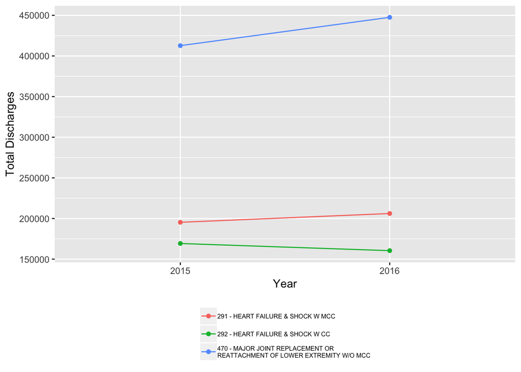

```r
top_3 <- med %>% gather(tot_discharges_15,
               tot_discharges_16,
               key = tot_by_yr,
               value = tot_discharges) %>%
  mutate(year = case_when(
    tot_by_yr == "tot_discharges_16" ~ "2016",
    tot_by_yr == "tot_discharges_15" ~ "2015"
  )) %>%
  group_by(drg_definition, year) %>%
  summarise(tot_discharges = sum(tot_discharges)) %>%
  arrange(desc(tot_discharges))

top_3 <- top_3[1:6, ]

top_3 %>%
  ggplot(aes(x = year, y = tot_discharges, color = str_wrap(drg_definition, 40))) +
  geom_point() +
  geom_line(aes(group = drg_definition)) +
  theme(legend.position = "bottom", legend.direction = "vertical",
        legend.text=element_text(size=6), legend.title = element_blank()) +
  xlab("Year") +
  ylab("Total Discharges")
```

Between 2015 and 2016 there was an increase in the number of major joint replacements and heart failure with MCC, but a decrease in the number of heart failures with CC.

One way to further contextualize data on the change in the number of diagnoses of a certain condition is to describe the percent change in occurrences of conditions. In this, case I filter for conditions which have over 25000 diagnoses to improve the stability of estimates and to assess the most common of medical conditions in the elderly.

```r
med %>%
  group_by(drg_definition) %>%
  filter(sum(tot_discharges_16) >= 25000) %>%
  summarise(percent_chng = (sum(tot_discharges_16)/sum(tot_discharges_15)-1) * 100,
            discharges_16 = sum(tot_discharges_16)) %>%
  arrange(desc(percent_chng))
```

```
## # A tibble: 48 x 3
##    drg_definition                               percent_chng discharges_16
##    <chr>                                               <dbl>         <int>
##  1 853 - INFECTIOUS & PARASITIC DISEASES W O.R…        35.5          74014
##  2 252 - OTHER VASCULAR PROCEDURES W MCC               31.4          30047
##  3 483 - MAJOR JOINT/LIMB REATTACHMENT PROCEDU…        17.1          42693
##  4 330 - MAJOR SMALL & LARGE BOWEL PROCEDURES …        12.8          40900
##  5 065 - INTRACRANIAL HEMORRHAGE OR CEREBRAL I…         9.94         96024
##  6 470 - MAJOR JOINT REPLACEMENT OR REATTACHME…         8.44        447523
##  7 189 - PULMONARY EDEMA & RESPIRATORY FAILURE          7.76        124455
##  8 246 - PERC CARDIOVASC PROC W DRUG-ELUTING S…         7.75         28816
##  9 291 - HEART FAILURE & SHOCK W MCC                    5.54        206146
## 10 682 - RENAL FAILURE W MCC                            4.37        106412
## # ... with 38 more rows
```

```r
med %>%
  group_by(drg_definition) %>%
  filter(sum(tot_discharges_16) >= 25000) %>%
  summarise(percent_chng = (sum(tot_discharges_16)/sum(tot_discharges_15)-1) * 100,
            discharges_16 = sum(tot_discharges_16)) %>%
  arrange(percent_chng)
```

```
## # A tibble: 48 x 3
##    drg_definition                               percent_chng discharges_16
##    <chr>                                               <dbl>         <int>
##  1 192 - CHRONIC OBSTRUCTIVE PULMONARY DISEASE…       -26.4          33432
##  2 195 - SIMPLE PNEUMONIA & PLEURISY W/O CC/MCC       -20.5          28666
##  3 191 - CHRONIC OBSTRUCTIVE PULMONARY DISEASE…       -16.3          80565
##  4 194 - SIMPLE PNEUMONIA & PLEURISY W CC             -15.0         111429
##  5 066 - INTRACRANIAL HEMORRHAGE OR CEREBRAL I…       -14.9          30660
##  6 314 - OTHER CIRCULATORY SYSTEM DIAGNOSES W …       -14.6          27974
##  7 293 - HEART FAILURE & SHOCK W/O CC/MCC             -10.3          39018
##  8 812 - RED BLOOD CELL DISORDERS W/O MCC              -9.26         48628
##  9 378 - G.I. HEMORRHAGE W CC                          -8.70        110005
## 10 313 - CHEST PAIN                                    -8.43         44683
## # ... with 38 more rows
```

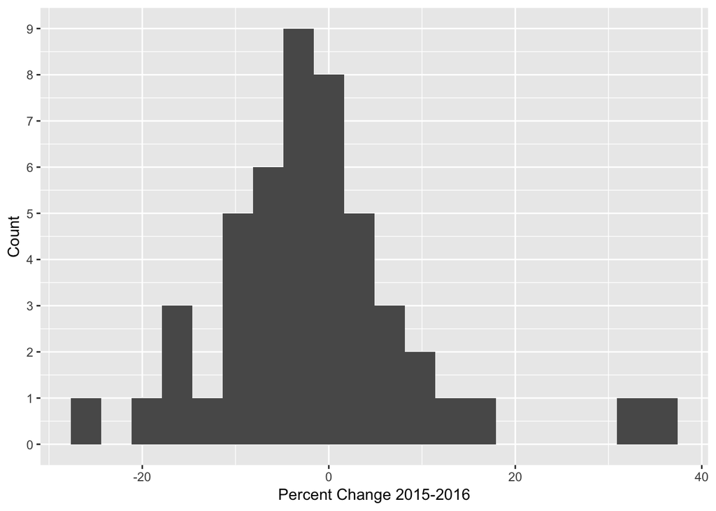

```r
med %>%
  group_by(drg_definition) %>%
  filter(sum(tot_discharges_16) >= 25000) %>%
  summarise(percent_chng = (sum(tot_discharges_16)/sum(tot_discharges_15) - 1) * 100) %>%
  ggplot(aes(x = percent_chng)) +
  geom_histogram(bins = 20) +
  scale_x_continuous("Percent Change 2015-2016", breaks = seq(-40, 40, 20)) +
  scale_y_continuous("Count", breaks = seq(0, 10, 1))
```

#### Medicare Charges by State

In this section, I analyze data related to inpatient charges across states in the US. Using the techniques specified in the Methodology document from the CMS, I recalculate totals to enable grouped summary statistics by state. The data in its original form contains total discharges and then averages for medicare payments, total payments and total covered charges. By multiplying these averages by the total discharges, I am able to recreate the totals that the CMS used to calculate the averages. This allows me to perform more accurate grouped summaries by state. Taking the average of averages weights observations unequally.

```r
med <- med %>% mutate(
  tot_cov_charges_15 = avg_covered_charges_15 * tot_discharges_15,
  tot_cov_charges_16 = avg_covered_charges_16 * tot_discharges_16,
  tot_payments_15 = avg_tot_payments_15 * tot_discharges_15,
  tot_payments_16 = avg_tot_payments_16 * tot_discharges_16,
  tot_medicare_payments_15 = avg_medicare_payments_15 * tot_discharges_15,
  tot_medicare_payments_16 = avg_medicare_payments_16 * tot_discharges_16
)
```

##### Highest Total Payments By State

The units for each graph are in dollars.

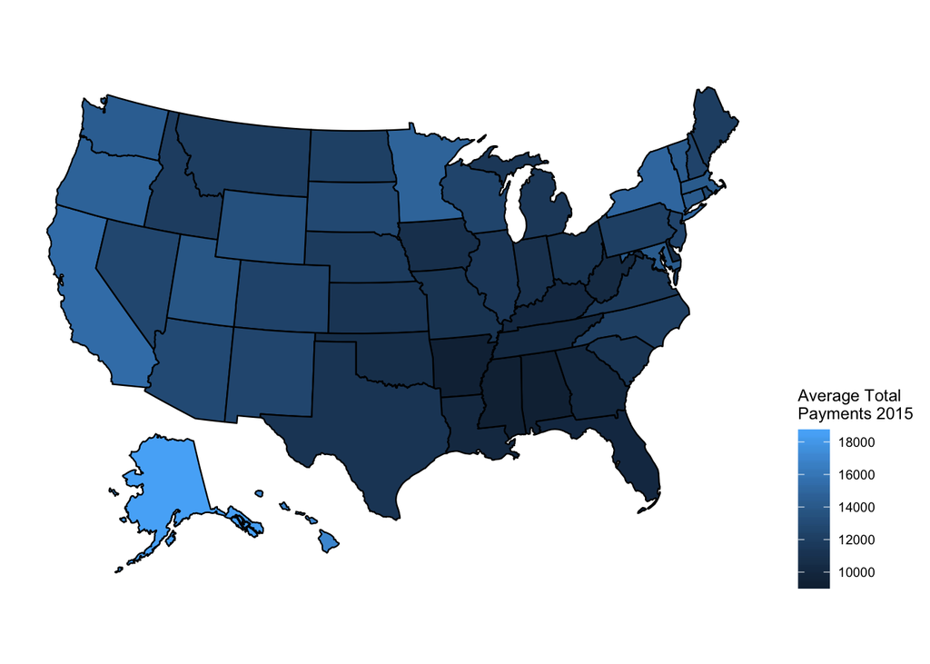

```r
avg_total_payments <- med %>%
  rename("state" = "provider_state") %>%
  group_by(state) %>%
  summarise(avg_total_payments_15 = sum(tot_payments_15)/sum(tot_discharges_15),
            avg_total_payments_16 = sum(tot_payments_16)/sum(tot_discharges_16),
            diff = avg_total_payments_16 - avg_total_payments_15
            ) %>%
  arrange(desc(avg_total_payments_15, avg_total_payments_16))

plot_usmap(data = avg_total_payments, values = "avg_total_payments_15") +
  scale_fill_continuous(str_wrap("Average Total Payments 2015", 15)) +
  theme(legend.position = "right")
```

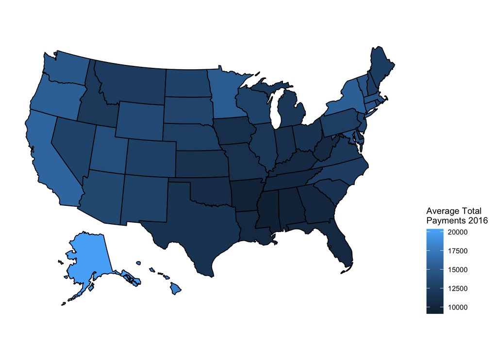

```r
plot_usmap(data = avg_total_payments, values = "avg_total_payments_16") +
  scale_fill_continuous(str_wrap("Average Total Payments 2016", 15)) +
  theme(legend.position = "right")
```

The next graph represents the change in average total payments by state between 2015 and 2016.

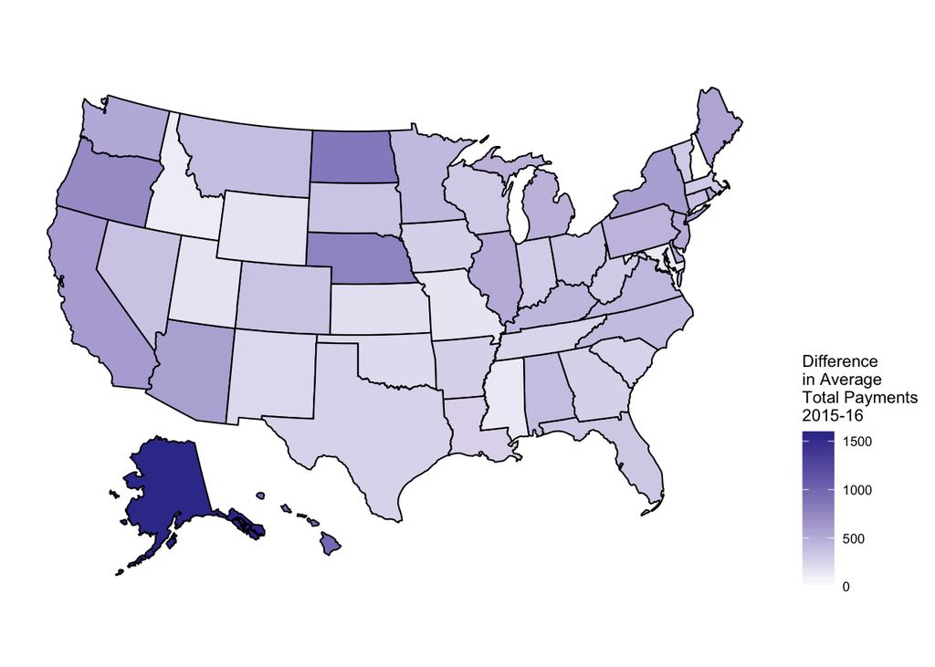

```r
plot_usmap(data = avg_total_payments, values = "diff") +
  scale_fill_gradient2(str_wrap("Difference in Average Total Payments 2015-16", 15)) +
  theme(legend.position = "right")
```

#### Individual Contributions by State

```r
med <- med %>% mutate(tot_copay_deductible_16 = tot_payments_16 - tot_medicare_payments_16,
                      tot_copay_deductible_15 = tot_payments_15 - tot_medicare_payments_15)


avg_copay_deductible <- med %>%
  rename("state" = "provider_state") %>%
  group_by(state) %>%
  summarise(avg_copay_16 = sum(tot_copay_deductible_16)/sum(tot_discharges_16),
         avg_copay_15 = sum(tot_copay_deductible_15)/sum(tot_discharges_15),
         diff = avg_copay_16 - avg_copay_15)


avg_copay_deductible %>%
  arrange(desc(avg_copay_16, avg_copay_15)) %>%
  print(n = 51)
```

```
## # A tibble: 51 x 4
##    state avg_copay_16 avg_copay_15     diff
##    <chr>        <dbl>        <dbl>    <dbl>
##  1 DC           3820.        3786.   33.6
##  2 HI           3519.        3331.  188.
##  3 UT           2970.        3162. -192.
##  4 PA           2627.        2527.  101.
##  5 AK           2549.        2491.   57.8
##  6 WI           2546.        2433.  113.
##  7 VA           2542.        2413.  129.
##  8 NY           2518.        2430.   88.1
##  9 WA           2451.        2358.   93.4
## 10 CT           2417.        2358.   59.7
## 11 MN           2345.        2360.  -15.6
## 12 NC           2323.        2193.  129.
```

[output cut: 39 more lines]

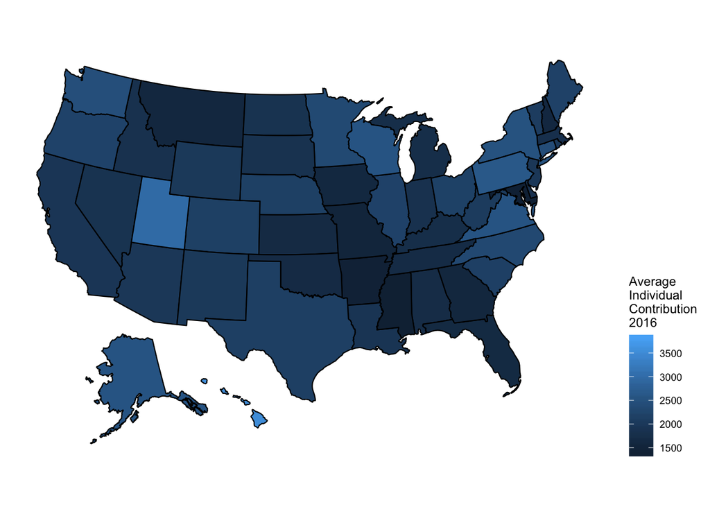

```r
plot_usmap(data = avg_copay_deductible, values = "avg_copay_16") +
  scale_fill_continuous(str_wrap("Average Individual Contribution 2016", 15)) +
  theme(legend.position = "right")
```

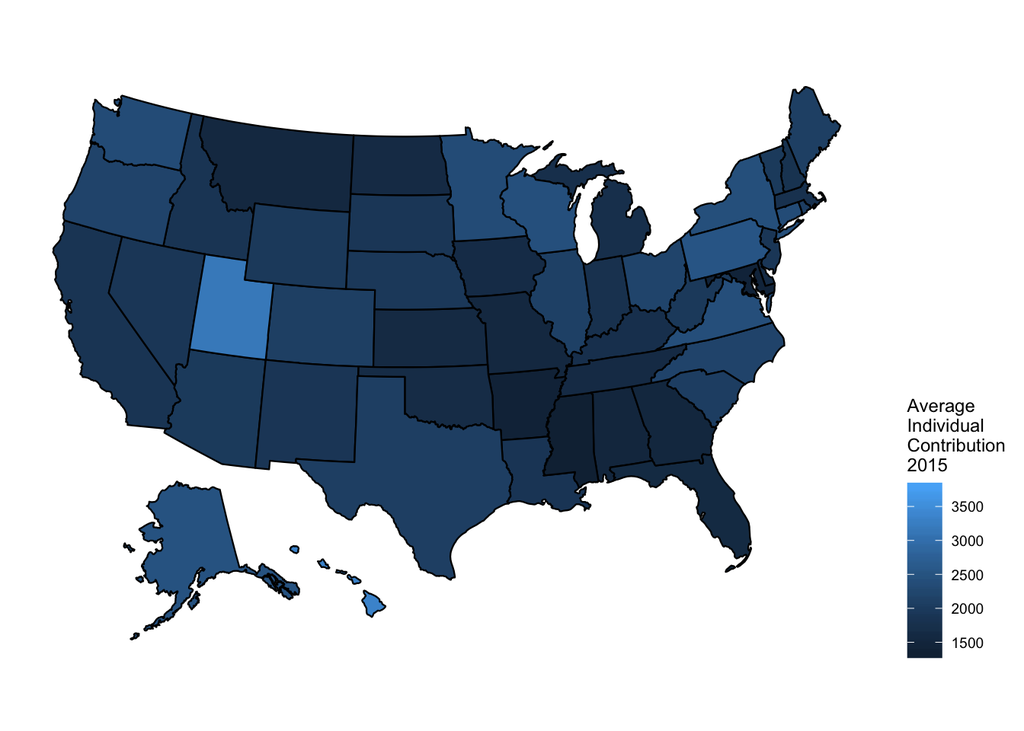

```r
plot_usmap(data = avg_copay_deductible, values = "avg_copay_15") +
  scale_fill_continuous(str_wrap("Average Individual Contribution 2015", 15)) +
  theme(legend.position = "right")
```

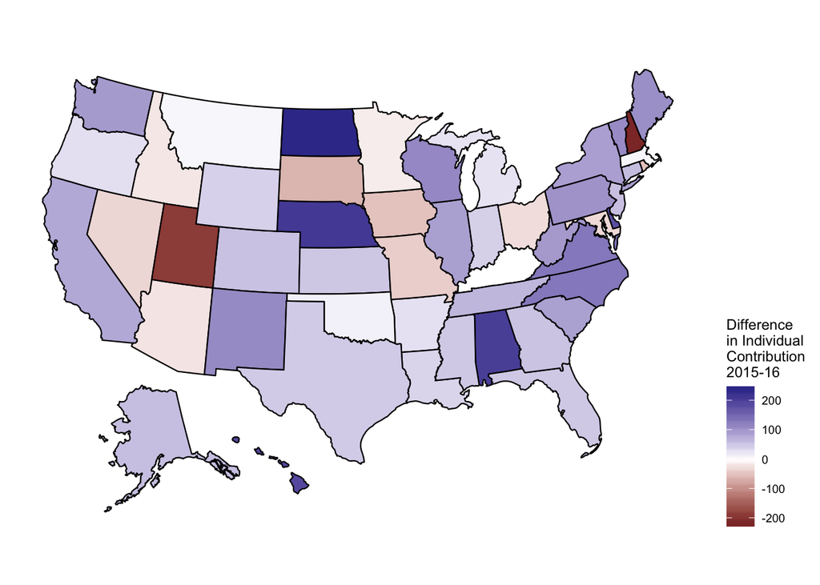

```r
plot_usmap(data = avg_copay_deductible, values = "diff") +
  scale_fill_gradient2(str_wrap("Difference in Individual Contribution 2015-16", 15)) +
  theme(legend.position = "right")
```

##### Medicare contributions by state

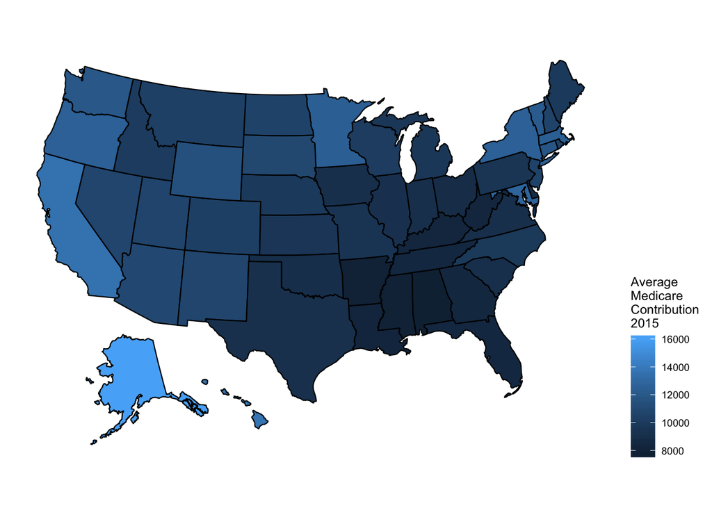

```r
med_payments <- med %>%
  rename("state" = "provider_state") %>%
  group_by(state) %>%
  summarise(avg_med_payments_15 = sum(tot_medicare_payments_15)/sum(tot_discharges_15),
            avg_med_payments_16 = sum(tot_medicare_payments_16)/sum(tot_discharges_16),
            diff = avg_med_payments_16 - avg_med_payments_15)

plot_usmap(data = med_payments, values = "avg_med_payments_15") +
  scale_fill_continuous(str_wrap("Average Medicare Contribution 2015", 15)) +
  theme(legend.position = "right")
```

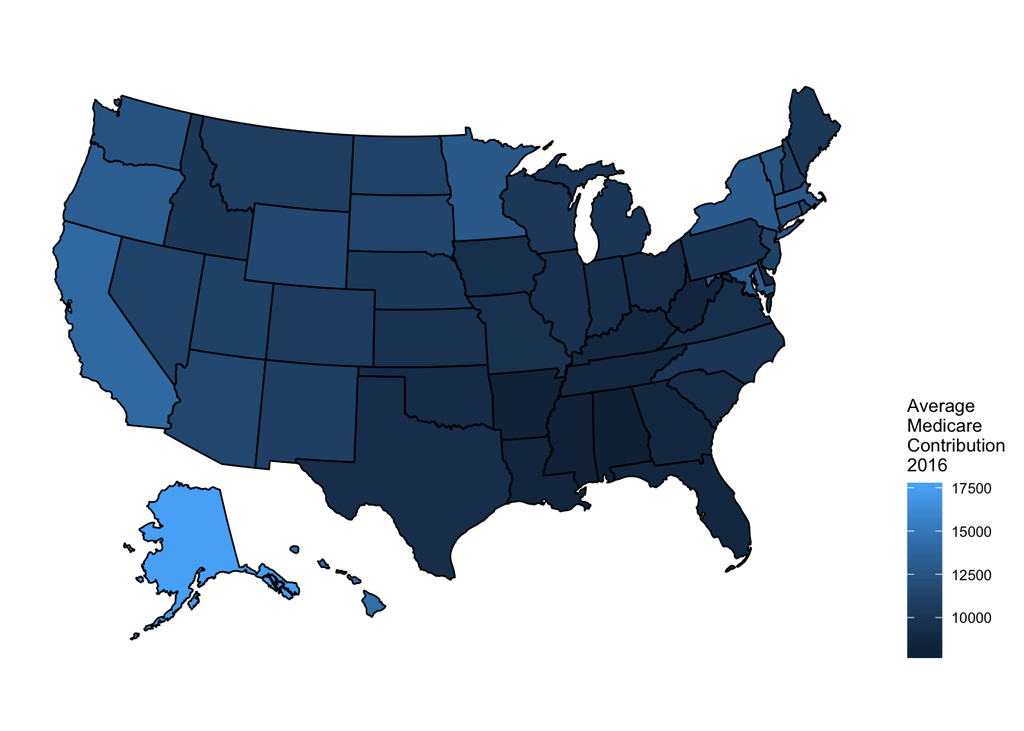

```r
plot_usmap(data = med_payments, values = "avg_med_payments_16") +
  scale_fill_continuous(str_wrap("Average Medicare Contribution 2016", 15)) +
  theme(legend.position = "right")
```

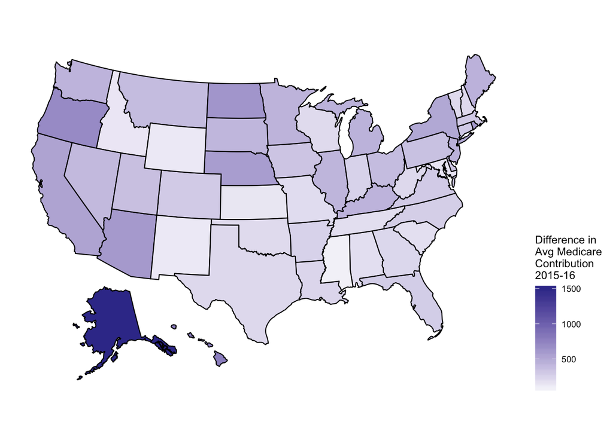

```r
plot_usmap(data = med_payments, values = "diff") +
  scale_fill_gradient2(str_wrap("Difference in Avg Medicare Contribution 2015-16", 15)) +
  theme(legend.position = "right")
```